# The Economic Order Quantity, and What a Wrong One Costs

Manuel D. Rossetti, PhD P.E.

## Agenda

- The classical economic order quantity, worked end to end on a real item
- When to place the order, and the case where the obvious answer is wrong
- What a *wrong* order quantity costs
- Why the answer to that last question licenses ordering in cases

Same assumptions as last session: demand known and constant, replenishment instantaneous, no shortages permitted.

## Where We Left Off

Last session we derived one cycle and obtained four classical models by switching assumptions off. Today we live inside the simplest of them.

$$\mathit{TC}(Q) = \frac{k\lambda}{Q} + c\lambda + \frac{hQ}{2}
\qquad\Longrightarrow\qquad
Q^{*} = \sqrt{\frac{2k\lambda}{h}}$$

And we carry one check forward:

At $Q^{*}$ the **ordering and holding terms are equal**. If they are not, your $Q$ is not optimal.

## The Trade-Off, Drawn

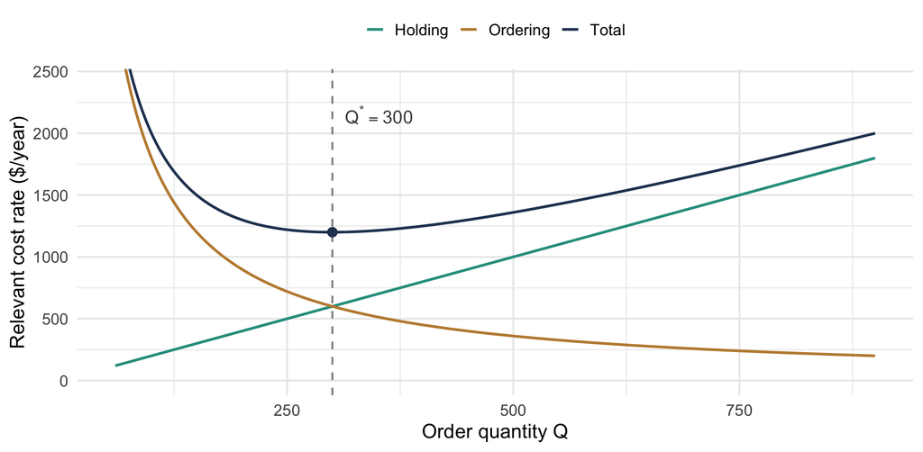

## Reading the Curve

$\lambda = 2400$, $k = \$75$, $h = \$4$.

Notice what is **not** on the chart. The purchase term $c\lambda$ is absent, because it does not move with $Q$. What is plotted is the **relevant** cost, the only part the decision can touch.

**Ordering** falls steeply at small $Q$: a small order means many orders a year.

**Holding** rises in a straight line: average stock is $Q/2$.

They **cross exactly at $Q^{*}$**. That is the equal-terms property, made visible.

And look at the total near its minimum. It is **flat over a wide range**. Hold that thought; it is the second half of today.

## The Item

A product is demanded at $\lambda = 220$ units per year. It costs $c = \$1{,}200$ per unit. Placing an order costs $k = \$800$, and the carrying charge is $i = 0.18$ per year. No shortages are allowed.

*What is stocked?* One item at one location.

*What is the demand process?* Continuous, known, and constant.

*When is inventory reviewed?* Continuously; the position is always known.

*What triggers replenishment, and how much?* The position reaching $r$, for a fixed quantity $Q$.

*What happens to unmet demand?* Nothing. Shortages are not permitted.

## Step 1, the Holding Cost

The carrying charge is a rate on **value**, so

$$h = i\,c$$

$$h = (0.18)(1200) = \mathbf{\$216} \text{ per unit per year}$$

Holding cost is almost never estimated directly. It is built from what the unit is worth, because the dominant cost of holding is the **capital tied up**.

## Step 2, the Order Quantity

$$Q^{*} = \sqrt{\frac{2k\lambda}{h}}$$

$$Q^{*} = \sqrt{\frac{2(800)(220)}{216}} = \sqrt{\frac{352{,}000}{216}}$$

$$Q^{*} = \mathbf{40.37} \text{ units}$$

Forty units at a time, against annual demand of 220. The item turns over about five and a half times a year.

## Step 3, the Cycle Length

$$T^{*} = \frac{Q^{*}}{\lambda} = \frac{40.37}{220} = 0.1835 \text{ year}$$

$$0.1835 \times 365 = \mathbf{66.98} \text{ days}$$

Choosing $Q$ and choosing $T$ are the **same decision**.

Which one you hand to an operating group depends on what they can act on. A warehouse that ships on a weekly cycle finds a *time* far easier to use than a quantity.

## Step 4, the Total Cost

$$\mathit{TC}^{*} = \sqrt{2k\lambda h} + c\lambda$$

$$\sqrt{2(800)(220)(216)} = \$8{,}719.63$$

$$c\lambda = (1200)(220) = \$264{,}000$$

$$\mathit{TC}^{*} = \mathbf{\$272{,}719.63} \text{ per year}$$

## The Check

Split the $8,719.63 and see whether the halves match:

$$\frac{k\lambda}{Q^{*}} = \frac{800(220)}{40.37} = \$4{,}359.82$$

$$\frac{hQ^{*}}{2} = \frac{216(40.37)}{2} = \$4{,}359.82$$

Equal, as they must be.

Do this every time. **Unequal halves mean $Q$ is not optimal**, and the direction of the inequality tells you which way to move.

## Notice What Dominates

| Component | Amount | Share |
| --- | --- | --- |
| Purchase, $c\lambda$ | $264,000.00 | 96.8% |
| Ordering | $4,359.82 | 1.6% |
| Holding | $4,359.82 | 1.6% |
| **Total** | **$272,719.63** |  |

The purchase term is **97% of the total** and is untouched by the decision. We buy 220 units a year whatever $Q$ is.

The $8,719.63 is the **entire quantity the lot sizing decision can influence**. Comparing policies on total cost, with the purchase term in, makes every alternative look nearly identical.

## A Closing Observation

$$T^{*} = 66.98 \text{ days} = 9.57 \text{ weeks}$$

Suppose this item ships on a weekly truck. Ordering every **ten weeks** fits a rhythm the warehouse already has.

What does that cost? Hold the question. We answer it exactly before the end of the session, and the answer is “almost nothing.”

You will usually find that the better answer.

## When Do We Order?

Nothing so far has said **when**, only how much.

With demand and lead time both known, the timing is exact. Place the order so it arrives at the instant stock would otherwise reach $-\hat{B}$.

- $L$, the replenishment **lead time**, known and constant
- $r$, the **reorder point**, the inventory *position* at which we order

$r$ is a level of **inventory position**, not of stock on hand. Position counts what is already on order. A rule that triggers on on-hand stock alone will order again, and again, while the first order is still in transit.

## The Simple Case

When $L \le T$, demand over the lead time is $\lambda L$:

$$r = \lambda L - \hat{B}$$

With no backorders permitted this is just $r = \lambda L$.

For our item, with a seven day lead time:

$$r = 220\left(\frac{7}{365}\right) = \mathbf{4.22} \text{ units}$$

Order when the position falls to about four units. Seven days is well under the 67 day cycle, so this is the easy case.

## Now Make the Lead Time Longer

Suppose the lead time is **longer than a cycle**.

Then one or more replenishment orders are **already outstanding** when the next is placed.

The reorder point must cover only the demand **not already covered** by those outstanding orders.

$$r = \left(L - \left\lfloor \frac{L}{T} \right\rfloor T\right)\lambda - \hat{B}$$

The floor counts the whole cycles inside the lead time. What is left is the remainder, and only that remainder is uncovered.

## A Different Item, Six Lead Times

$\lambda = 100$ units per month, $Q^{*} = 154.92$, so $T^{*} = 1.5492$ months.

| $L$ (months) | $\lfloor L/T \rfloor$ | $r$ |
| --- | --- | --- |
| 0.25 | 0 | 25.00 |
| 1.00 | 0 | 100.00 |

| $L$ (months) | $\lfloor L/T \rfloor$ | $r$ |
| --- | --- | --- |
| 0.25 | 0 | 25.00 |
| 1.00 | 0 | 100.00 |
| 1.60 | 1 | **5.08** |

Look at that third row.

## The Full Table

| $L$ (months) | $\lfloor L/T \rfloor$ | $r$ |
| --- | --- | --- |
| 0.25 | 0 | 25.00 |
| 1.00 | 0 | 100.00 |
| 1.60 | 1 | **5.08** |
| 2.00 | 1 | 45.08 |
| 3.00 | 1 | 145.08 |
| 4.00 | 2 | 90.16 |

**The reorder point is not monotone in the lead time.** A lead time of 1.6 months needs a *far lower* reorder point than one of 1.0 months.

## Reorder Point Against Lead Time

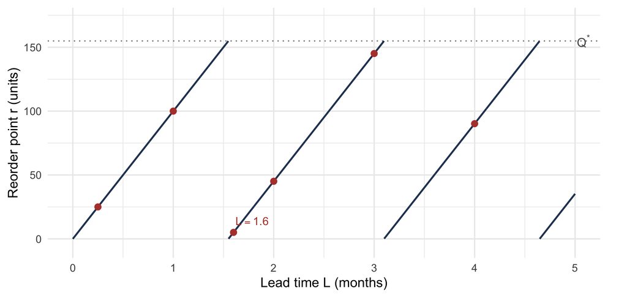

## Why It Sawtooths

Each time the lead time passes a whole multiple of the cycle, **one more order is already in transit**.

That order covers a full cycle of demand, so the reorder point drops by a full $Q^{*}$ and starts climbing again.

The largest $r$ can ever be is therefore just under

$$\lambda T^{*} = Q^{*} = 154.92 \text{ units}$$

A system that computes $r = \lambda L$ is wrong for **every** lead time past the first cycle, and it is wrong in the expensive direction: it orders far too early and carries the excess forever.

## Nobody Orders 40.37 of Anything

Our formula returned $Q^{*} = 40.37$. A warehouse orders 40, or a case of 48, or whatever fits the truck.

So the real question is not “what is the optimum?” but:

> **How much do we lose by not being at it?**

The answer turns out to govern far more than rounding. It is why we can force items onto a shared cycle, fit a delivery schedule, and round to powers of two, all of which we do later in the course.

## The Penalty Formula

Let $C(Q)$ be the **relevant** cost, the part that depends on $Q$:

$$C(Q) = \frac{k\lambda}{Q} + \frac{hQ}{2}, \qquad C^{*} = \sqrt{2k\lambda h}$$

Take the ratio and substitute $Q^{*} = \sqrt{2k\lambda/h}$:

$$\frac{C(Q)}{C^{*}} = \frac{1}{2}\left(\frac{Q}{Q^{*}} + \frac{Q^{*}}{Q}\right)$$

## Look at What Is Not In It

$$\frac{C(Q)}{C^{*}} = \frac{1}{2}\left(\frac{Q}{Q^{*}} + \frac{Q^{*}}{Q}\right)$$

No $k$. No $\lambda$. No $h$. No $c$.

**The penalty depends only on the ratio** $Q/Q^{*}$, and on nothing else about the item.

A $3 fastener and a $40,000 transformer, each ordered 20% away from their own optimum, give up exactly the same *percentage*.

## Wrong by Half, Wrong by Double

Order 50% too much, $Q/Q^{*} = 3/2$:

$$\frac{1}{2}\left(\frac{3}{2} + \frac{2}{3}\right) = \frac{13}{12} = 1.083$$

That is **8.3%** of the relevant cost.

Order half as much, $Q/Q^{*} = 1/2$:

$$\frac{1}{2}\left(\frac{1}{2} + 2\right) = 1.25$$

That is **25%**.

Order **double**, and it is also 25%. The formula is symmetric in $Q/Q^{*}$ and its reciprocal.

## The Penalty Curve

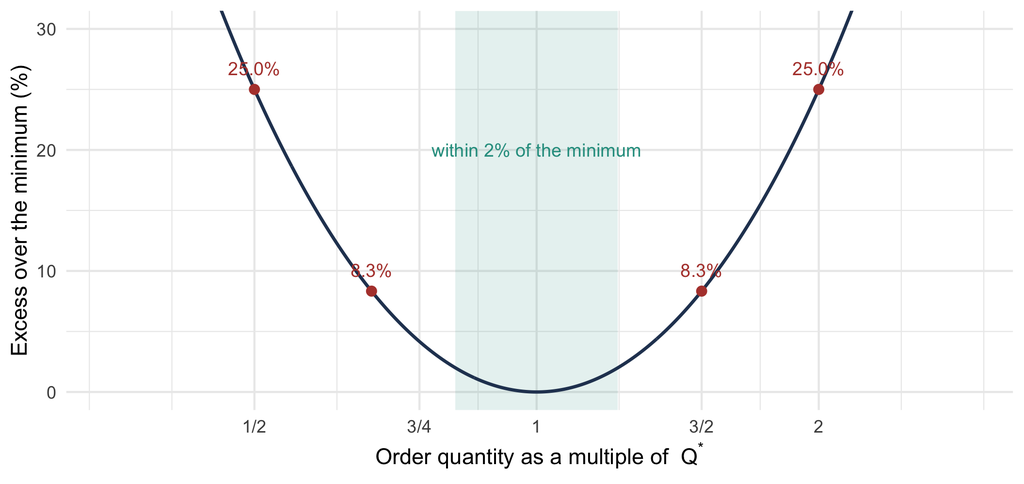

## The Band That Matters

Solve $\tfrac{1}{2}(x + 1/x) = 1.02$:

$$x^{2} - 2.04x + 1 = 0
\qquad\Longrightarrow\qquad
x = 0.819 \text{ or } 1.221$$

**Anything between 82% and 122% of $Q^{*}$ costs within 2% of the minimum.**

That is a very wide target. It is the single most useful fact in this chapter, and it is what the rest of the course spends.

## Ordering in Cases

An item has $\lambda = 1500$ per year, $k = \$120$, $c = \$40$, $i = 0.22$, so $h = \$8.80$ and

$$Q^{*} = \sqrt{\frac{2(120)(1500)}{8.80}} = 202.26 \text{ units}$$

It is supplied in **cases of 48**. The two nearest case quantities are $4 \times 48 = 192$ and $5 \times 48 = 240$.

| Order | $Q/Q^{*}$ | Penalty | Extra per year |
| --- | --- | --- | --- |
| 192 (4 cases) | 0.9493 | 0.136% | **$2.41** |
| 240 (5 cases) | 1.1866 | 1.467% | $26.11 |

Order **four cases**. Two dollars and change a year buys a quantity the supplier will actually ship.

## The Weekly Truck, Settled

Back to the item we worked. Its optimal cycle was $T^{*} = 9.57$ weeks, and we asked what ordering every **ten** weeks would cost.

Ten weeks of demand is

$$Q = 220\left(\frac{10}{52}\right) = 42.31 \text{ units},
\qquad
\frac{Q}{Q^{*}} = \frac{42.31}{40.37} = 1.048$$

$$\frac{1}{2}\left(1.048 + \frac{1}{1.048}\right) = 1.0011$$

**0.11%**, or about **$9.60 a year** against a relevant cost of $8,719.

Nine dollars and sixty cents to put the item on a truck that was leaving anyway.

## What Flatness Licenses

- Round to a whole number, a case, a pallet
- Fit a delivery schedule you already run
- Put several items on one shared cycle
- Round a cycle length to a power of two

All of these move $Q$ off its optimum, and all of them are nearly free.

**And what it does not license**

Flatness is a statement about the **relevant** cost, which excludes the purchase term.

Introduce a **quantity discount** and the purchase term stops being constant. It becomes the thing the decision moves, it is far larger than the relevant cost, and it is **discontinuous** at each price break.

Next session.

## What We Did Today

**The EOQ worked end to end.** $h = ic$, then $Q^{*}$, then $T^{*}$, then $\mathit{TC}^{*}$, then the equal-halves check.

**The purchase term dominates the total and is irrelevant to the decision.** 97% of $272,719 could not be moved by any choice of $Q$.

**The reorder point reads the position, not the shelf**, and it is **not monotone** in the lead time. $r = \lambda L$ is wrong past the first cycle.

**The penalty depends only on $Q/Q^{*}$.** Between $0.82Q^{*}$ and $1.22Q^{*}$ you give up under 2%.

## For Next Time

**Read before next session:** *Quantity Discounts*, and *Performance Measures for the Cycle*.

Today’s material was *Lead Time and the Reorder Point* and *Sensitivity of the Order Quantity*.

Next session:

- All-units discounts, where the whole order reprices at a break, and why the break quantities themselves become candidates
- Incremental discounts, where only the units above a break reprice, and why they produce **smaller** orders
- The service measures the general cycle delivers, which we get for nothing from the four segments

The flat cost curve does **not** survive a price schedule. Come prepared to stop trusting it.

⌂ Index